# Visualizing Social Patterns with Census Data

## Setting up

Download this file from GitHub and then open it in R Studio (`File>Open File`). Choose the Visual view if it doesn’t automatically populate.

[figure not shown]

To run the code, either click the small green “Run Current Chunk” button in the top right of each code chunk, or put your cursor anywhere in the chunk then hit `Cntrl + Shift + Enter` (for a PC) or `Cmd + Shift + Enter` (for a Mac).

We’ll start by loading the necessary packages for this workflow. In R, a package is a collection of tools that are used for specific kinds of workflows. The packages are all open source, and you can synthesize as needed within your own code.

```r
# verify whether you need these packages, and install if so
if (!require(dplyr)) install.packages("dplyr")
if (!require(ggplot2)) install.packages("ggplot2")
if (!require(stringr)) install.packages("stringr")
if (!require(tidycensus)) install.packages("tidycensus")
```

```r
# now load the libraries
library(dplyr)      # for managing data tables
library(ggplot2)    # for data visualization
library(stringr)    # for filtering string columns
library(tidycensus) # for using the Census API
```

## Explore and query Census data

The US Census Bureau publishes much of its data on via the [Census Data API](https://www.census.gov/data/developers/guidance/api-user-guide.html). If you know what you are looking for, the API is often a more efficient way to query data than by navigating and downloading from the Census website.

That said, you *really* need to understand the structure of Census data in order to use the API. So in this section we’ll briefly recap Census products, geographies, and structure of content. You can and should explore data in the [Explore Census Data interface](https://data.census.gov/) first to understand what data to query.

We’ll start by setting up an API call. To get started, you need to obtain a free [Census API key](https://api.census.gov/data/key_signup.html). Save this somewhere secure, and remember not to share it on public platforms (e.g. when you share your code on a portfolio…)

```r
# set your API key
census_api_key("fd874e212346a3d3f3e27fce3fb3cc7dfce3c4e1")
```

#### **Data products**

Spend some time reviewing the [API Discovery Tool](https://api.census.gov/data.html) for a list of the data products available. Most of the time, we are interested in the demographic, socioeconomic, housing, and employment data from the Decennial Census and American Community Survey.

The [Decennial Census](https://www.census.gov/programs-surveys/decennial-census.html) has been conducted every decade since 1790. It is the longest and most comprehensive record of American social geography, covering thousands of variables. Like any *census*, it is intended to be a comprehesive account of every person living in the country (though there are well-known issues around enumerating some [“hard-to-count populations”](https://www.census.gov/newsroom/blogs/random-samplings/2023/10/understanding-undercounted-populations.html)).

The [ACS](https://www.census.gov/programs-surveys/acs.html) is a companion to the Decennial Census, run every year since 2005. It includes many of the same variables counted in the Census, available on a more regularly updated basis. But like any *survey*, the ACS counts only a small sample of the overall population (typically about 3.5 million households annually, out of ~127 million households nationally). For this reason ACS data are always published in two forms, an *estimate* and a *margin of error*. Furthermore, data are aggregated into different temporal estimates:

- *1 year estimates* use data from only the year in question. They are only available for some variables at the coursest geographic scales.
- *3 year estimates* use data from the year in question plus the preceding two years (e.g. a 2021-2023 ACS 3 year estimate is an estimate of 2023 values, based on an average of data from 2021 through 2023). They are available for most variables and some finer geographic scales.
- *5 year estimates* use data from the year in question plus the preceding four years (e.g. a 2019-2023 ACS 3 year estimate is an estimate of 2023 values, based on an average of data from 2019 through 2023). They are available for nearly all variables at nearly all geographic scales.

For this exercise, we’ll work with data from the ACS 5 year estimates, for the most recent year available. To do that, we’ll first pull up a list of all the variables in that data product. Here is a [list of options](https://walker-data.com/tidycensus/articles/basic-usage.html#searching-for-variables) for defining the parameters on that `load_variables()` function.

```r
# query metadata from the api, naming the year and data product
variablelist <- load_variables(year= 2023, dataset = "acs5")

# now view the list. Note that this will also show up in the Environment tab on the top right corner. You can view anything from that environment by double-clicking it.
View(variablelist)
```

#### Querying the API

For my workflow, I want to explore whether there’s a relationship between the percent of households that are rent burdened and the amount of new housing built in counties across the US. From this, I could do some data storytelling around the idea that the solution to the housing crisis lies in building more housing. That supply-side approach is common in the YIMBY movement and the ‘abundance agenda’, political movements that argue for deregulating housing development through reforms to zoning and building codes.

```r
# define a list of variables, including more intuitive names
variables <- c(RenterHU_sum  = "B25070_001",
               RenterHU_30to35ofInc_sum = "B25070_007",
               RenterHU_35to40ofInc_sum = "B25070_008",
               RenterHU_40to49ofInc_sum = "B25070_009",
               RenterHU_over50ofInc_sum = "B25070_010",
               HouseUnits_sum = "B25034_001",
               HouseUnits_built2020orlater = "B25034_002",
               HouseUnits_built2010to2019 = "B25034_003"
               )
```

```r
# set up an API query
data <- get_acs(geography = "county",    # all counties in the US
                variables = variables,   # all variables defined in the list above
                output = "wide",         # row = observation, column = variable
                year = 2023,             # most recent year
                geometry = TRUE          # include spatial boundary data
                )
# see the total rows and columns of the data
dim(data)
```

```
[1] 3222   19
```

```r
#list the column names
ls(data)
```

```
 [1] "GEOID"                        "geometry"                     "HouseUnits_built2010to2019E"
 [4] "HouseUnits_built2010to2019M"  "HouseUnits_built2020orlaterE" "HouseUnits_built2020orlaterM"
 [7] "HouseUnits_sumE"              "HouseUnits_sumM"              "NAME"
[10] "RenterHU_30to35ofInc_sumE"    "RenterHU_30to35ofInc_sumM"    "RenterHU_35to40ofInc_sumE"
[13] "RenterHU_35to40ofInc_sumM"    "RenterHU_40to49ofInc_sumE"    "RenterHU_40to49ofInc_sumM"
[16] "RenterHU_over50ofInc_sumE"    "RenterHU_over50ofInc_sumM"    "RenterHU_sumE"
[19] "RenterHU_sumM"
```

You now have a data frame called `data` in your Environment. You can open it to see the structure of what we downloaded. Note that ACS data publishes both estimated values (variables will include ‘E’ in the column name) and margins of error on those estimates (will include ‘M’ in the column name).

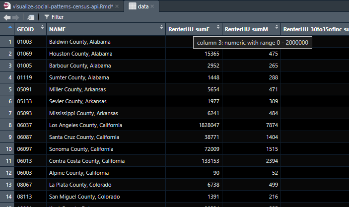

Finally, we need to do a bit of data processing to get the data into a shape that will allow further visualization and analysis.

```r
# use dplyr tools to clean the data
data <- data %>%
  rename_with(~ gsub("E$", "", .x), .cols = everything()) %>%
  mutate(RentBurdened_pct = (RenterHU_30to35ofInc_sum + RenterHU_35to40ofInc_sum +
           RenterHU_40to49ofInc_sum + RenterHU_over50ofInc_sum) / RenterHU_sum * 100,
         NewHomes_pct =  (HouseUnits_built2010to2019 + HouseUnits_built2020orlater) /
           HouseUnits_sum * 100)
```

```r
# now we'll calculate some descriptive statistics just to verify it worked
mean(data$RentBurdened_pct)
```

```
[1] 36.51085
```

```r
mean(data$NewHomes_pct)
```

```
[1] 8.303947
```

## Visualize data patterns

The first thing we might want to know is where are places with higher/lower rent burdens and higher/lower rates of new homes. To do that we’ll use the `ggplot2` library to create [choropleth maps](https://www.axismaps.com/guide/choropleth). These are a common data visualization that use the color of polygons to visualize data values.

`ggplot2` is based on a statistical visualization concept called the “[grammar of graphics](https://www.tandfonline.com/doi/abs/10.1198/jcgs.2009.07098)”. This approach is basically a layering structure, in which you first define a plot space (defining what the x and y are for a graph) and then add on additional layers of information.

You build graphics by adding these layers, with a + for each layer:

- **ggplot**() defines the plot layer itself
- **geom** adds geometric layers onto the plot
- **aes** mapping defines the aesthetics of a layer
- **stat** functions calculate derivative numbers for use in a graphic
- **position** adjustments change how layers are ordered or rendered
- **coordinate** functions would alter how the points are displayed (e.g. using a map instead of a cartesian grid)
- **facet** functions define how multiple charts are arranged on the ggplot layer
- **theme** borrows from a library of existing themes to style the graphic

#### Choropleth maps

We’ll start by mapping the geographic pattern of our variables. This will identify regions of high/low values in each of the variables.

```r
# first we'll drop Alaska and Hawaii and overseas territories to focus on only the lower 48 states
## FIPS codes to exclude
exclude_list <- c("02", "15", "60", "66", "69", "72", "78")
lower48 <- data %>%
  filter(!str_sub(GEOID, 1, 2) %in% exclude_list)
```

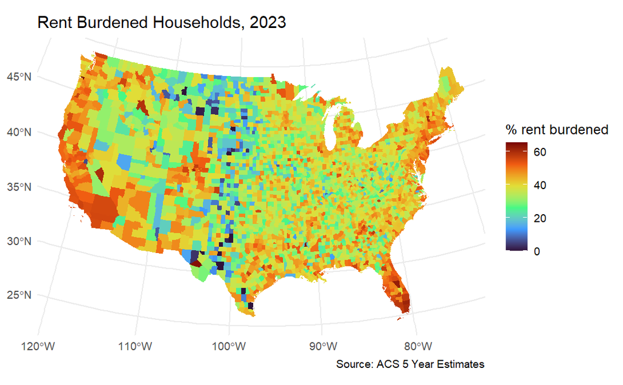

```r
# now map rent burden
ggplot(data = lower48) +
  geom_sf(aes(fill = RentBurdened_pct), color = NA) +
  coord_sf(crs = 102010) +
  scale_fill_viridis_c(option = "turbo", name = "% rent burdened") +
  labs(
    title = "Rent Burdened Households, 2023",
    caption = "Source: ACS 5 Year Estimates"
  ) +
  theme_minimal()
```

```r
NA
```

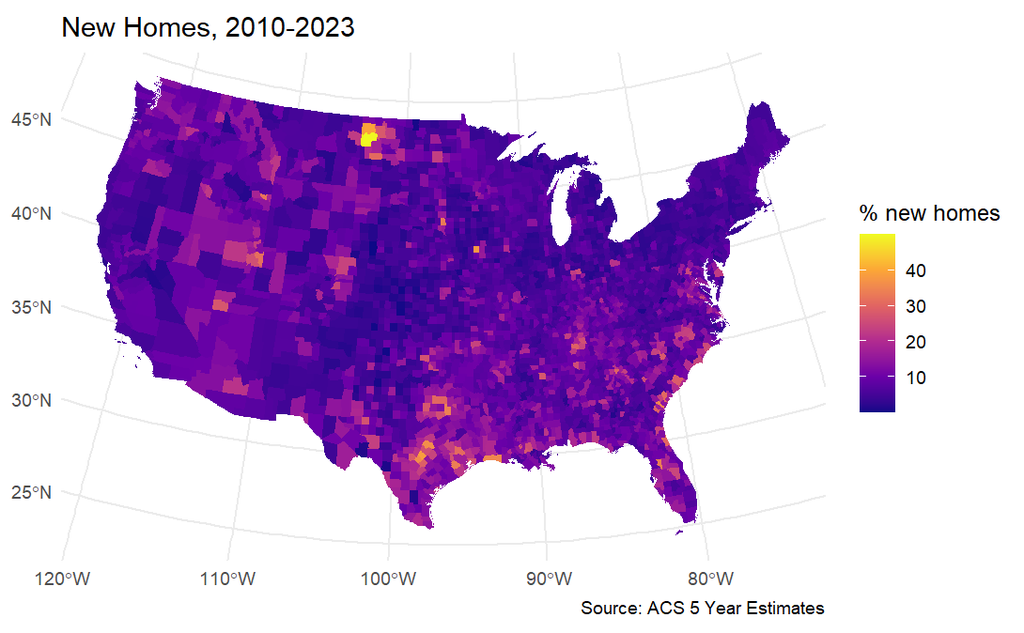

```r
# now map rent burden
ggplot(data = lower48) +  # defines the data space
  geom_sf(aes(fill = NewHomes_pct), color = NA) +  # viz type = map
  coord_sf(crs = 102010) +   # a relevant map projection for the region by EPSG code
  scale_fill_viridis_c(option = "plasma",
                       name = "% new homes") +  # define color fill
  labs(
    title = "New Homes, 2010-2023",
    caption = "Source: ACS 5 Year Estimates"  # add text
  ) +
  theme_minimal()  # chose a theme
```

#### Scatterplot

Visually evaluating the maps, it looks like there might be some association between the two variables. But other kinds of data visualizations may be more effective for understanding any potential pattern. We’ll create a scatterplot, a visualization technique that plots one variable against the other, so you can see the overall pattern.

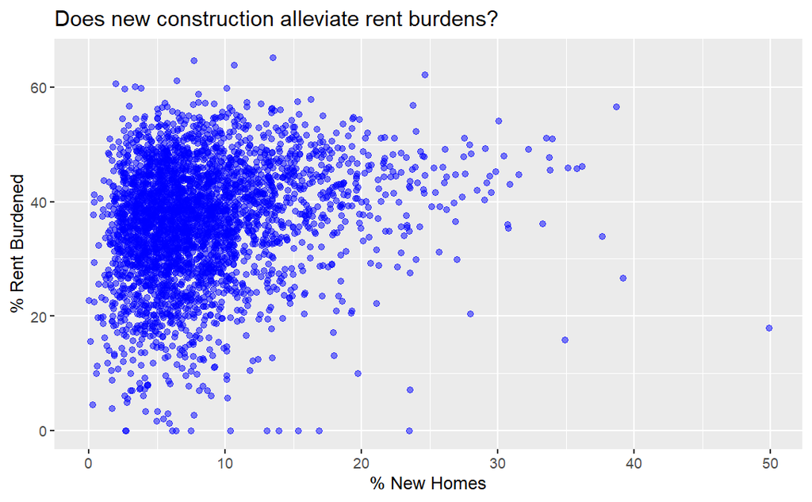

```r
# create a scatterplot
ggplot(data = data,   # define the data space
       aes(x = NewHomes_pct, y = RentBurdened_pct)) +   # define x and y
  geom_point(size = 1.5,  # size of symbol
             color = "blue", # color as name or RBG vector
             alpha = .5) +  # transparency
  labs(
    title = "Does new construction alleviate rent burdens?",
    y = "% Rent Burdened",
    x = "% New Homes"
  )
```

On this plot, each dot represents a county. The dots’ position represent their values of the x and y variable. One other key piece of information we need to understand, however, is the population of the counties (or, in this case, the total number of renters). We can modify the plot to use a third variable as a size parameter:

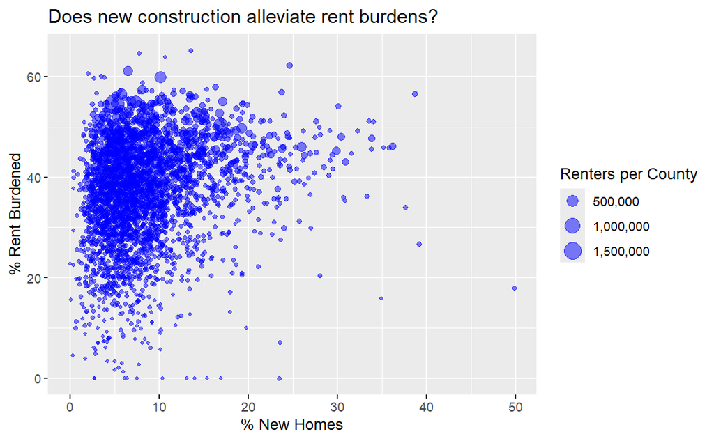

```r
# create a scatterplot
ggplot(data = data,   # define the data space
       aes(x = NewHomes_pct, y = RentBurdened_pct, size = RenterHU_sum)) +
  geom_point(color = "blue", # color as name or RBG vector
             alpha = .5) +  # transparency
  scale_size_continuous(labels = scales::comma) +
  labs(
    title = "Does new construction alleviate rent burdens?",
    y = "% Rent Burdened",
    x = "% New Homes",
    size = "Renters per County"
  )
```

The point cloud tells us very useful information about the relationship between the two variables. Specifically, we can tell stories about:

1. The relative trend in the cloud. Trending upward (from bottom left to top right) indicates a positive relationship. Trending downward indicates a negative relationship.
2. The relative dispersion of the cloud. A tightly clustered cloud indicates a strong association between variables. A randomly distributed cloud indicates a weak association.

## Statistical testing

While visualization is useful, it only *describes* a visual pattern. For persuasive data storytelling, however, we need to present evidence that analyzes the pattern and evaluates uncertainty around the analysis. We’ll address this with two related tests: correlation and linear regression.

#### Correlation

Correlation tests assess whether the variables are associated with each other. The null hypothesis is that the variables are not associated. The alternative hypothesis is that they are.

For data with this structure, we should use a test called Pearson’s R correlation coefficient. It will generate a correlation coefficient that ranges from -1 to 1.

- 0 indicates no correlation.
- The directionality of the coefficient indicates whether the correlation is positive or negative (the direction the point cloud slopes toward).
- The relative magnitude of the coefficient indicates the strength of correlation (the relative compactness or dispersion of the point cloud).

```r
# a basic correlation test
cor(x = data$NewHomes_pct,
    y = data$RentBurdened_pct,
    method = "pearson")
```

```
[1] 0.2030688
```

But we also need to understand whether the Pearson’s R value is statistically ‘significant’. To that, we’ll run a test that generate a series of extra metrics including:

- a t-test, which tests whether R is 0 or not 0. Larger values indicate that R is more likely to be not 0.
- p-value for that t-test, which gives a level of statistical confidence (e.g.,“x is correlated with y, at the 99% level of confidence”)
- a confidence interval, stating that we are certain the actual value of R is between these values at a given level of confidence (e.g., “we are 95% certain the true value of R is between __ and __”)

```r
cor.test(x = data$NewHomes_pct,
         y = data$RentBurdened_pct,
         method = "pearson")
```

```
    Pearson's product-moment correlation

data:  data$NewHomes_pct and data$RentBurdened_pct
t = 11.768, df = 3220, p-value < 2.2e-16
alternative hypothesis: true correlation is not equal to 0
95 percent confidence interval:
 0.1697275 0.2359458
sample estimates:
      cor
0.2030688
```

Based on these tests, we can say that my variables are positively but weakly correlated (r = .203). I am confident the variables are correlated with a 99.9% level of significance. And I am 95% confident that the actual correlation is somewhere between 0.17 and 0.236.

#### Simple linear regression

A correlation test will tell us that two variables are associated. But, famously, *correlation does not equal causation* (for some hilarious illustrations of this point, see Tyler Vigin’s [*Spurious Correlations*](https://www.tylervigen.com/spurious-correlations) blog).

To get closer to measuring causal patterns, we can use regression models to ask if one variable *predicts* the behavior of the other variable. The basic version of this is ‘simple’ linear regression, which fits a line through the point cloud of your scatterplot in the most efficient manner possible.

The model is a simple algebraic line:

y = 𝛂 + 𝛃(x)

where:

- y is the predicted value of y,
- 𝛂 is the intercept of the line. It can be interpreted as the value we would expect to see for y if x is 0.
- 𝛃 is the slope of the line. It can be interpreted as how we predict y to change if x increased by one unit.

```r
# define a regression model
lm(formula = RentBurdened_pct ~ NewHomes_pct, data = data)
```

```
Call:
lm(formula = RentBurdened_pct ~ NewHomes_pct, data = data)

Coefficients:
 (Intercept)  NewHomes_pct
      33.256         0.392
```

We also want to evaluate the overall performance of the model. This will give us some additional metrics including:

- whether the beta coefficient is statistically significant, and at what level (the t value and p value next to the coefficient estimates)
- the R-squared, which measures the proportion of the behavior of y that is explained by the model

```r
# save the model
model <- lm(formula = RentBurdened_pct ~ NewHomes_pct, data = data)

# view the results
summary(model)
```

```
Call:
lm(formula = RentBurdened_pct ~ NewHomes_pct, data = data)

Residuals:
    Min      1Q  Median      3Q     Max
-42.452  -5.672   0.975   6.773  28.361

Coefficients:
             Estimate Std. Error t value Pr(>|t|)
(Intercept)  33.25591    0.32769  101.49   <2e-16 ***
NewHomes_pct  0.39197    0.03331   11.77   <2e-16 ***
---
Signif. codes:  0 ‘***’ 0.001 ‘**’ 0.01 ‘*’ 0.05 ‘.’ 0.1 ‘ ’ 1

Residual standard error: 9.975 on 3220 degrees of freedom
Multiple R-squared:  0.04124,   Adjusted R-squared:  0.04094
F-statistic: 138.5 on 1 and 3220 DF,  p-value: < 2.2e-16
```

Finally, we’ll add this model line to the scatterplot using a `geom_smooth` layer. The method parameter will use the same `y ~ x` formula we used above. It will also add a visualization of the confidence interval, which you can specify using a level parameter.

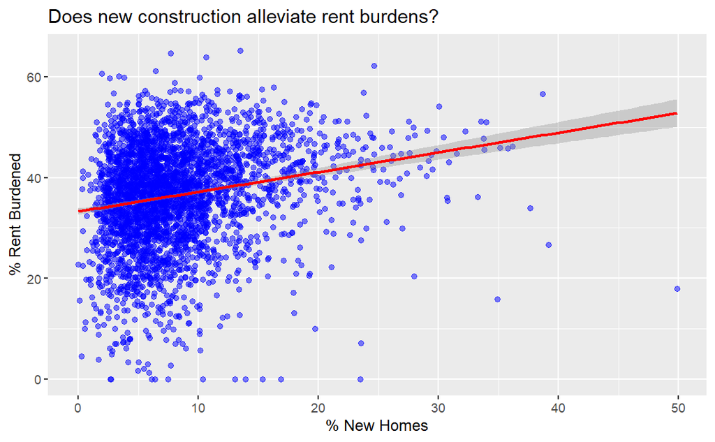

```r
# create a scatterplot
ggplot(data = data,
       aes(x = NewHomes_pct, y = RentBurdened_pct)) +
  geom_point(color = "blue", alpha = .5) +
  geom_smooth(method = "lm",  # use y ~ x
              level = 0.95,   # confidence interval around the line
              color = "red",
              show.legend = TRUE) +  # color of the line
  scale_size_continuous(labels = scales::comma) +
  labs(
    title = "Does new construction alleviate rent burdens?",
    y = "% Rent Burdened",
    x = "% New Homes"
  )
```